# Loan slides

## Introduction

America’s first marketplace lending platform, with over $9 billion in funded loans. This data set contains 113,937 loans with 81 variables on each loan.

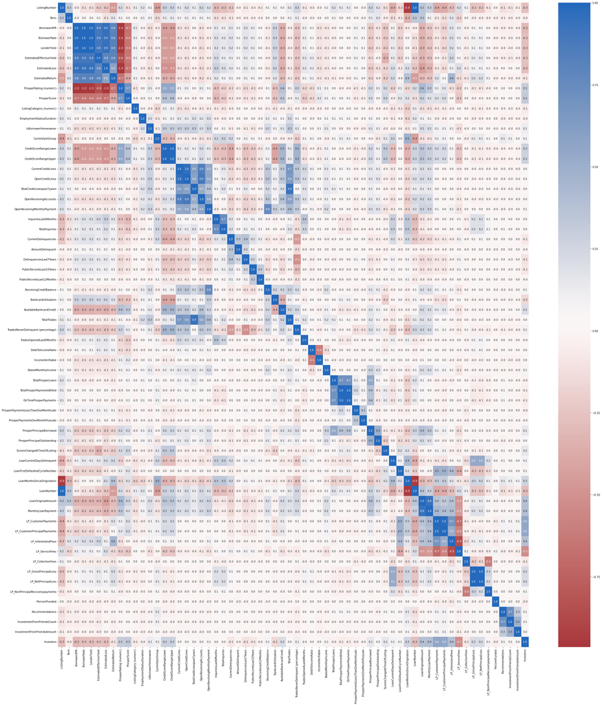

## What is the structure of data?

This data set contains 113,937 loans with 81 variables on each loan, including loan amount, borrower rate (or interest rate), current loan status, borrower income, and many others.

### What the main feature(s) of interest in your dataset?

I saw in this data, the main feature that interest in data is BorrowerAPR or Borrower rate.

Another interesting variable is the prosper score, This information can be used to build a predictive model for risk management in bank or financial.

### What other features in the dataset do you think will help support your investigation into your feature(s) of interest?

BorrowerAPR or Borrower rate and this feature may affected by EmployeeStatus, loan amount, prosper rate, prosper score.

## Univariate Exploration

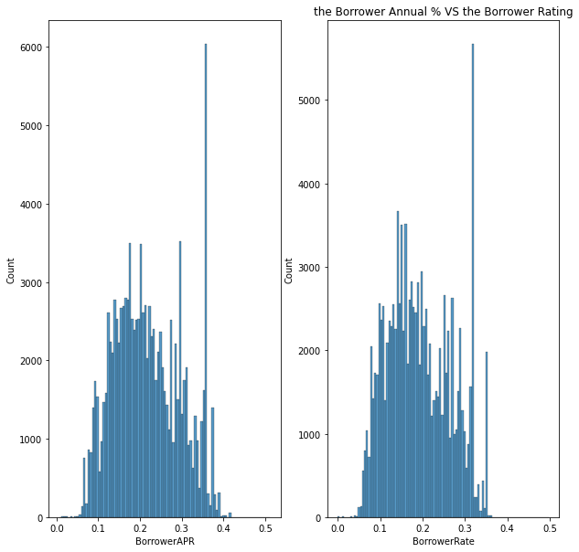

from the past two plots shoes the Borrower Annual % is geater than Borrower Rate that me the Borrower Annual is equal to Borrower Rate plus small fees

**Prosper Score**

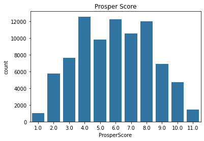

**Occupation**

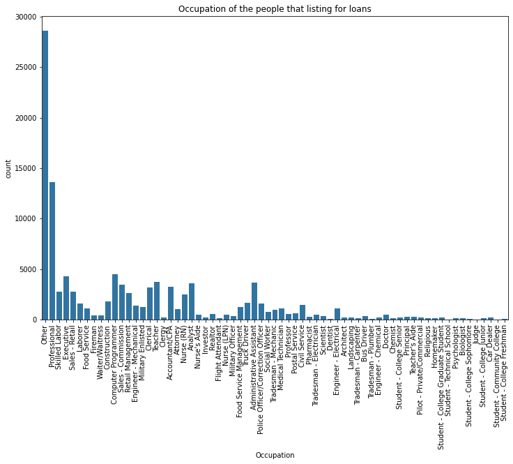

This Plot Show That Most people that need loan working like a freelance job and the second most is Professional.

**EmploymentStatus**

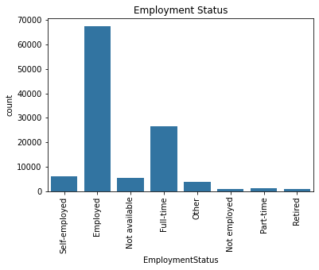

Most people that listing is employed.

### Discuss the distribution of your variables of interest?

the Borrower Annual % is geater than Borrower Rate that me the Borrower Annual is equal to Borrower Rate plus small fees.

## Bivariate Exploration

**find relation between Borrower Annual % and Loan Amount**

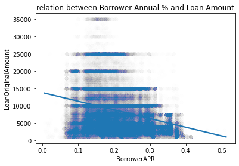

this plot shows that relation between Borrower Annual % and Loan Amount are negative so if APR is big the loan amount should be small and vise versu.

**Distribute Relation Between BorrowerAPR, ProsperRating (Alpha)**

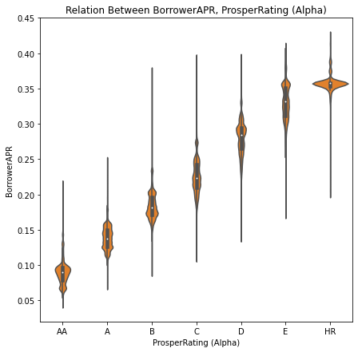

The plot show strong correlation between the prosper rating/score with the borrower’s APR. where **Prosper Rating** is assigned at the time the listing was created between AA - HR. Applicable for loans originated after July 2009.

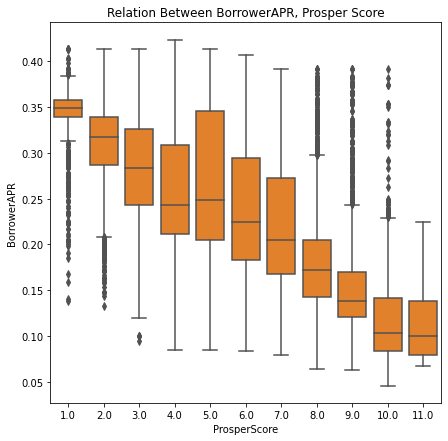

### Talk about some of the ralationship you observe?

this plot shows that relation between Borrower Annual % and Loan Amount are negative so if APR is big the loan amount should be small and vise versu.

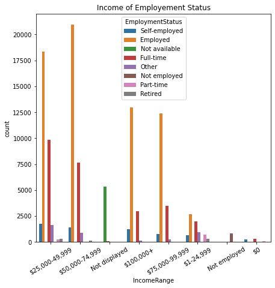

## Multivariate Exploration

**Relation Between Borrower APR and Loan Amount and Montly Patment**

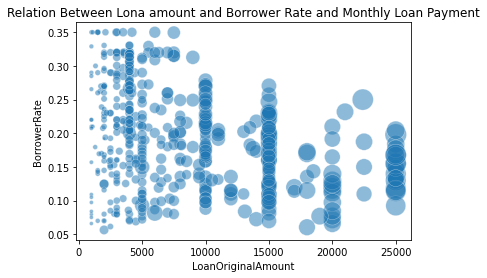

This Polt Shows That most of Higher Loan Amount need big Monthly Loan Payment and the Borrower Rate when it big it usually the loan amount be small

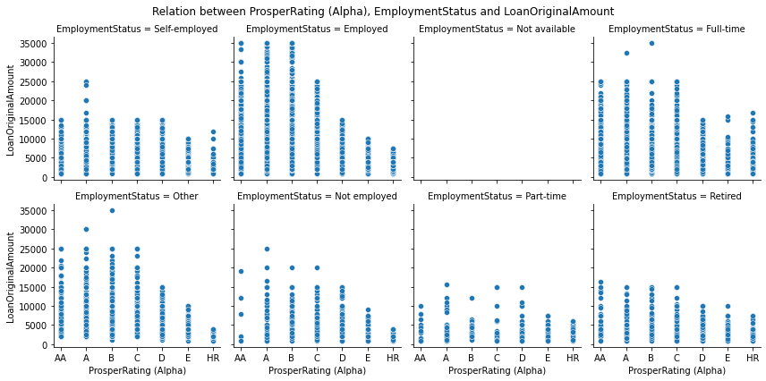

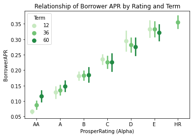

the borrower APR decrease with the increase of borrow term for people with HR-C raings. on the other hand the term increase in rating AA.